# Reproducible Research: Week 2 Programming Assignment

## Loading the csv file and summary

```r
library(ggplot2)
unzip("activity.zip")
dataSet<- read.csv("activity.csv")
head(dataSet)
```

```
##   steps       date interval
## 1    NA 2012-10-01        0
## 2    NA 2012-10-01        5
## 3    NA 2012-10-01       10
## 4    NA 2012-10-01       15
## 5    NA 2012-10-01       20
## 6    NA 2012-10-01       25
```

```r
dim(dataSet)
```

```
## [1] 17568     3
```

```r
summary(dataSet)
```

```
##      steps                date          interval
##  Min.   :  0.00   2012-10-01:  288   Min.   :   0.0
##  1st Qu.:  0.00   2012-10-02:  288   1st Qu.: 588.8
##  Median :  0.00   2012-10-03:  288   Median :1177.5
##  Mean   : 37.38   2012-10-04:  288   Mean   :1177.5
##  3rd Qu.: 12.00   2012-10-05:  288   3rd Qu.:1766.2
##  Max.   :806.00   2012-10-06:  288   Max.   :2355.0
##  NA's   :2304     (Other)   :15840
```

## 1.What is mean total number of steps taken per day?

### Number of steps per day

```r
SummedDataByDay <- aggregate(dataSet$steps, by=list(dataSet$date), sum)
names(SummedDataByDay)[1] ="date"
names(SummedDataByDay)[2] ="totalsteps"
head(SummedDataByDay,10)
```

```
##          date totalsteps
## 1  2012-10-01         NA
## 2  2012-10-02        126
## 3  2012-10-03      11352
## 4  2012-10-04      12116
## 5  2012-10-05      13294
## 6  2012-10-06      15420
## 7  2012-10-07      11015
## 8  2012-10-08         NA
## 9  2012-10-09      12811
## 10 2012-10-10       9900
```

### Make a histogram of the total number of steps taken each day

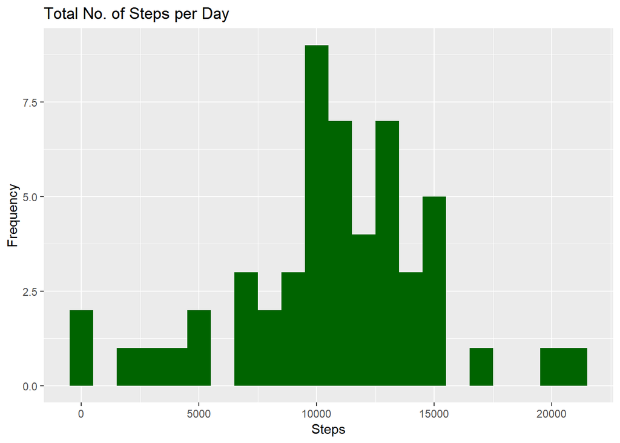

```r
ggplot(SummedDataByDay, aes(x = totalsteps)) +
  geom_histogram(fill = "darkgreen", binwidth=1000) +
  labs(title = "Total No. of Steps per Day", x = "Steps", y = "Frequency")
```

### Calculate and report the mean and median of the total number of steps taken per day

```r
mean(SummedDataByDay$totalsteps,na.rm=TRUE)
```

```
## [1] 10766.19
```

```r
median(SummedDataByDay$totalsteps,na.rm=TRUE)
```

```
## [1] 10765
```

## 2.What is the average daily activity pattern?

### Make a time series plot of the 5-minute interval (x-axis) and the average number of steps taken, averaged across all days (y-axis)

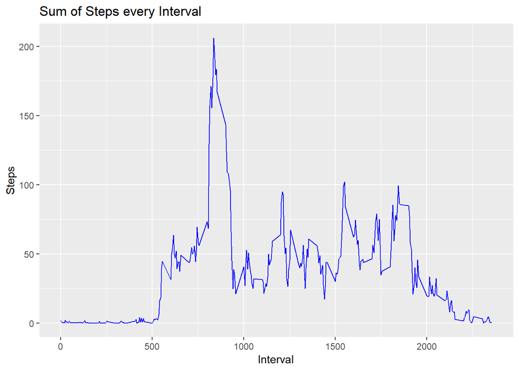

```r
dataSetNA <- is.na(dataSet$steps)
cleanBase <- dataSet[!dataSetNA,]

no_NASubset <- dataSet[!dataSetNA,]
MeanDataByInterval <- aggregate(no_NASubset$steps, by=list(no_NASubset$interval), mean)

names(MeanDataByInterval)[1] ="Interval"
names(MeanDataByInterval)[2] ="Steps"

ggplot(MeanDataByInterval, aes(x = Interval, y=Steps)) +
  labs(title = "Sum of Steps every Interval", x = "Interval", y = "Steps")+
  geom_line(color="blue")
```

### Which 5-minute interval, on average across all the days in the dataset, contains the maximum number of steps?

```r
maxInterval <- MeanDataByInterval[which(MeanDataByInterval$Steps==max(MeanDataByInterval$Steps)),]
maxInterval
```

```
##     Interval    Steps
## 104      835 206.1698
```

## 3.Imputing missing values

### Calculate and report the total number of missing values in the dataset (i.e. the total number of rows with NAs)

```r
missingValues <- sum(dataSetNA)
missingValues
```

```
## [1] 2304
```

### Devise a strategy for filling in all of the missing values in the dataset. The strategy does not need to be sophisticated. For example, you could use the mean/median for that day, or the mean for that 5-minute interval, etc.

### Create a new dataset that is equal to the original dataset but with the missing data filled in.

```r
library(magrittr)
library(dplyr)
ReplaceWithMean <- function(x) replace(x, is.na(x), mean(x, na.rm = TRUE))
MeanData <- dataSet%>% group_by(interval) %>% mutate(steps= ReplaceWithMean(steps))
head(MeanData)
```

```
## # A tibble: 6 x 3
## # Groups:   interval [6]
##    steps date       interval
##    <dbl> <fct>         <int>
## 1 1.72   2012-10-01        0
## 2 0.340  2012-10-01        5
## 3 0.132  2012-10-01       10
## 4 0.151  2012-10-01       15
## 5 0.0755 2012-10-01       20
## 6 2.09   2012-10-01       25
```

### Make a histogram of the total number of steps taken each day and Calculate and report the mean and median total number of steps taken per day.

```r
FullSummedDataByDay <- aggregate(MeanData$steps, by=list(MeanData$date), sum)
names(FullSummedDataByDay)[1] ="Date"
names(FullSummedDataByDay)[2] ="TotalSteps"
head(FullSummedDataByDay,15)
```

```
##          Date TotalSteps
## 1  2012-10-01   10766.19
## 2  2012-10-02     126.00
## 3  2012-10-03   11352.00
## 4  2012-10-04   12116.00
## 5  2012-10-05   13294.00
## 6  2012-10-06   15420.00
## 7  2012-10-07   11015.00
## 8  2012-10-08   10766.19
## 9  2012-10-09   12811.00
## 10 2012-10-10    9900.00
## 11 2012-10-11   10304.00
## 12 2012-10-12   17382.00
## 13 2012-10-13   12426.00
## 14 2012-10-14   15098.00
## 15 2012-10-15   10139.00
```

### Summary of new data : mean & median

```r
summary(FullSummedDataByDay)
```

```
##          Date      TotalSteps
##  2012-10-01: 1   Min.   :   41
##  2012-10-02: 1   1st Qu.: 9819
##  2012-10-03: 1   Median :10766
##  2012-10-04: 1   Mean   :10766
##  2012-10-05: 1   3rd Qu.:12811
##  2012-10-06: 1   Max.   :21194
##  (Other)   :55
```

### Making a histogram

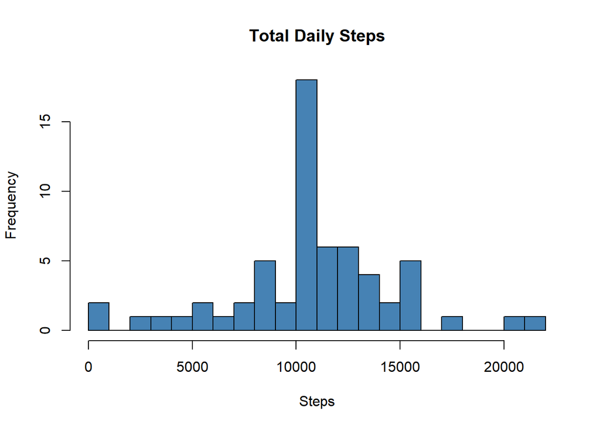

```r
hist(FullSummedDataByDay$TotalSteps, xlab = "Steps", ylab = "Frequency", main = "Total Daily Steps", breaks = 20, col="steelblue")
```

### Comparing the mean and median of Old and New data

```r
mean(FullSummedDataByDay$TotalSteps)
```

```
## [1] 10766.19
```

```r
median(FullSummedDataByDay$TotalSteps)
```

```
## [1] 10766.19
```

### Do these values differ from the estimates from the first part of the assignment?

Yes, the mean is the same but the median has risen 1.19 steps.

### What is the impact of imputing missing data on the estimates of the total daily number of steps?

The effect of using mean data per interval as a data impute method for missing values has increased overall data towards the mean.

## Are there differences in activity patterns between weekdays and weekends?

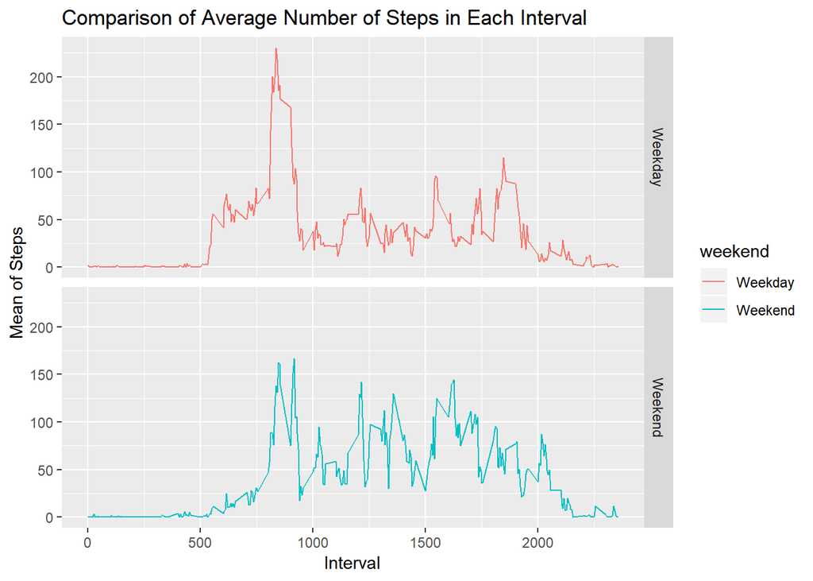

```r
library(ggplot2)
MeanData$date <- as.Date(MeanData$date)
MeanData$weekday <- weekdays(MeanData$date)
MeanData$weekend <- ifelse(MeanData$weekday=="Saturday" | MeanData$weekday=="Sunday", "Weekend", "Weekday" )

meandataweekendweekday <- aggregate(MeanData$steps , by= list(MeanData$weekend, MeanData$interval), na.omit(mean))
names(meandataweekendweekday) <- c("weekend", "interval", "steps")

ggplot(meandataweekendweekday, aes(x=interval, y=steps, color=weekend)) + geom_line()+
facet_grid(weekend ~.) + xlab("Interval") + ylab("Mean of Steps") +
    ggtitle("Comparison of Average Number of Steps in Each Interval")
```